# Recreating the LSTM in R

Because R is my native language, I redo the LSTM stuff in R

Import Keras:

```r
library(keras)
```

Set parameters:

```r
x_max = 20000
split_fraction = 0.8
# Number of elements pulled out of the time series for test and train data
num_samples = 1000
# Lengths of vectors for training and testing
delta_T = 500
# Define the time series as a list
deflist = list(sines = list(sin1 = list(omega = 2*pi/25, amp = 0.2),
                                                        sin2 = list(omega = 2*pi/500, amp = 2),
                                                        sin3 = list(omega = 2*pi/5000, amp = 10)),
                             noise = 0.1)
```

Build the time series.

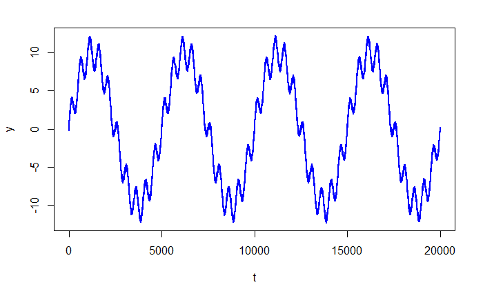

```r
t = seq(0, x_max)
y = rep(0, length(t))
for (element in deflist$sines) {
    y = y + element$amp * sin(element$omega * t)
}
y = y + rnorm(n = length(t), mean = 0, sd = deflist$noise)
plot(t, y, type = "l", lwd = 2, col = "blue")
```

To do the transformation, get min and max of time series and substract min and divide by difference

```r
min_y = min(y)
max_y = max(y)
y = (y - min_y)/(max_y - min_y)
```

For generating training and test data I chose another path. Instead of making the first 16000 elements of the time series the training data and the rest the test data, I pick `num_samples` vectors of length `delta_T + 1` out of the time series and use the last element as the target, the rest for training or predicting the target. The way to do this is pure idiomatic R :)

```r
idcs_mat = t(sapply(sample(seq(1, (x_max - delta_T - 2)), num_samples, TRUE),
                                        seq, length = delta_T + 1))
dim(idcs_mat)
```

```
[1] 1000  501
```

`num_samples` rows and `delta_T + 1` columns. Each row contains the numerical indices of a sample from the time series. The last column is the index of the target and gets extracted as a vector to define the targets:

```r
idcs_y = idcs_mat[, delta_T + 1] # extract last column
```

Sample the rows of `idcs_mat` to use for training:

```r
idcs_train = sample(x = 1:num_samples,
                                        size = round(num_samples*split_fraction),
                                        replace = FALSE)
```

Generate matrices that hold the samples from the time series

```r
x_train = t(apply(idcs_mat[idcs_train, seq(1, delta_T, by = 1)], 1, function(zeile) y[zeile]))
y_train = y[idcs_y[idcs_train]]
x_test = t(apply(idcs_mat[-idcs_train, seq(1, delta_T, by = 1)], 1, function(zeile) y[zeile]))
y_test = y[idcs_y[-idcs_train]]
x_train[1:10, 1:5]
```

```
           [,1]      [,2]      [,3]      [,4]      [,5]
 [1,] 0.6198194 0.6211611 0.6166265 0.6143818 0.6085172
 [2,] 0.9659576 0.9663179 0.9664942 0.9636201 0.9724051
 [3,] 0.3955270 0.3883449 0.3958564 0.3959421 0.3860940
 [4,] 0.9281787 0.9366528 0.9265029 0.9297000 0.9219576
 [5,] 0.7610700 0.7664476 0.7676133 0.7619197 0.7651687
 [6,] 0.9802199 0.9757419 0.9842903 0.9901874 0.9844609
 [7,] 0.2112272 0.2260149 0.2255811 0.2200768 0.2187312
 [8,] 0.6736202 0.6726694 0.6792107 0.6768187 0.6865905
 [9,] 0.8929046 0.8933416 0.8898016 0.8881568 0.8851004
[10,] 0.1731166 0.1721679 0.1750861 0.1690660 0.1692058
```

Again, each row contains one training example. However, to make the LSTM understand the data, it has to be transformed. In general, the data that goes into a Keras LSTM has to be in a three-dimensional array. The first dimension is the sample, the second dimensio is the time series, the third dimension is the number of the input. We have a 1D time series, so our third dimension has length one:

```r
# It is easier to just add the third dimension to the existing ones.
dim(x_train) = c(dim(x_train), 1)
dim(x_test) = c(dim(x_test), 1)
```

Now, we define the model:

```r
model = keras_model_sequential()
layer_lstm(object = model, units = 100, input_shape = c(delta_T, 1))
layer_dense(object = model, units = 1, activation = 'sigmoid')
compile(object = model, loss = "mean_squared_error", optimizer = "adam",
                metrics = "mae" )
```

Fitting the model for 10 epochs:

```r
fit(object = model, x = x_train, y = y_train, batch_size = 40, epochs = 10,
        validation_data = list(x_test, y_test))
```

```
Train on 800 samples, validate on 200 samples
```

Testing the output by plotting target versus predicted value:

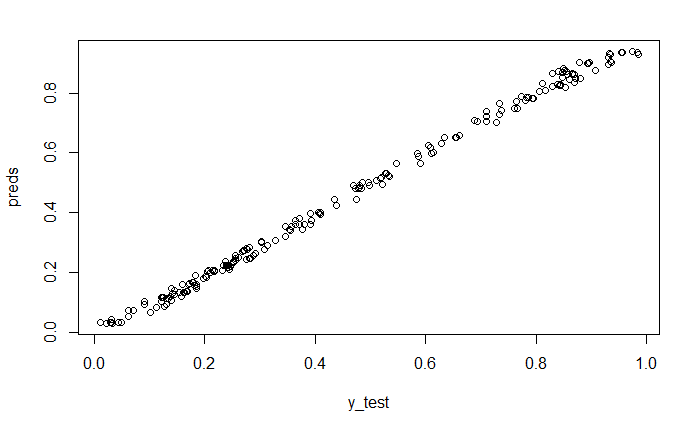

```r
preds = predict(model, x = x_test)
plot(y_test, preds)
```

Looks good.